# assignment_3_topic_modeling

```python
from sklearn.feature_extraction.text import TfidfVectorizer
from sklearn.decomposition import NMF
from sklearn.manifold import TSNE
```

```python
import multiprocessing as mp

import gensim
import spacy
import numpy as np
import pandas as pd
import matplotlib.pyplot as plt
from gensim.models import Phrases, LdaModel, LdaMulticore, CoherenceModel
from gensim.corpora import Dictionary
from sklearn.datasets import fetch_20newsgroups
```

```python
url = "https://storage.googleapis.com/msca-bdp-data-open/news/nlp_a_6_news.json"
news_df = pd.read_json(url, orient="records", lines=True).sample(n=5000, random_state=0)
```

```python
news_df.head()
```

|  | url | date | language | title | text |
| --- | --- | --- | --- | --- | --- |
| 3844 | https://www.kxii.com/prnewswire/2022/05/23/com... | 2022-05-23 | en | COMPUTEX 2022 Global Press Conference Industry... | COMPUTEX 2022 Global Press Conference Industry... |
| 3617 | https://www.bigrapidsnews.com/business/article... | 2022-06-09 | en | Moderna, Roku rise; Scotts Miracle-Gro, Charle... | Moderna, Roku rise; Scotts Miracle-Gro, Charle... |
| 2608 | https://www.devdiscourse.com/article/education... | 2022-04-12 | en | Create entrepreneurship ecosystem in districts... | Create entrepreneurship ecosystem in districts... |
| 3857 | https://www.seattletimes.com/seattle-news/heal... | 2022-04-30 | en | Connecticut Senate OKs bill that protects abor... | Connecticut Senate OKs bill that protects abor... |
| 1595 | https://www.breakinglatest.news/news/maturity-... | 2022-07-24 | en | Maturity, thanks from Fabio and Adriana: “Incl... | Maturity, thanks from Fabio and Adriana: “Incl... |

```python
news_df.shape
```

```
(5000, 5)
```

```python
def clean_text(corpus, spacy_pipeline, as_string=True, n_proc=2, batch_size=1000):
    """
    Cleans a sequence of text by applying some simple processing techniques.

    Args:
        corpus (Iterable): a sequence of text to be processed
        spacy_pipeline: the Spacy pipeline object for processing text
        n_proc (int): the number of processors to use for parallel processing
        batch_size (int): the number of texts to process in a single batch

    Returns:
        clean_sequence (list): a cleaned version of the original text
    """
    # container to store cleaned documents
    corpus_clean = []

    for doc in spacy_pipeline.pipe(
        corpus,
        disable=["ner"],
        n_process=n_proc,
        batch_size=batch_size
    ):

        # container for cleaned document tokens
        doc_tokens = [
            token.lemma_.lower()
            for token in doc
            if not token.is_stop and token.is_alpha and (len(token) > 1) and token.pos_ in ("NOUN", "VERB") # should consider if these are appropriate
        ]

        if as_string:
            corpus_clean.append(" ".join(doc_tokens))
        else:
            corpus_clean.append(doc_tokens)

    return corpus_clean
```

```python
# loading spacy model
# Define the model name

SPACY_MODEL = "en_core_web_sm"
nlp = spacy.load(SPACY_MODEL)
```

```python
# apply cleaning with clean_text function above

normalized_corpus = clean_text(
    corpus=news_df["text"].tolist(),
    spacy_pipeline=nlp,
    as_string=False
)
```

```python
len(normalized_corpus)
```

```
5000
```

### gensim expects each document to be a list of tokens, not a string

normalized_corpus[0]

```python
news_df.iloc[0, 4]
```

```
'COMPUTEX 2022 Global Press Conference Industry Leaders Gather to Unlock Future TrendsSkip to contentTexoma LocalExpert AdviceTexoma EatsNewsWeatherSportsSend Us Your News TipWatch LiveSearchHomepageLivestreamNewsTexasOklahomaRegionalInternationalNationalFireAccidentsCrimeEducationSend us YOUR news …
```

# LDA

```python
# training the phrases to find bigrams
bigram_phraser = Phrases(normalized_corpus) # this might require some eda, to decide min_count

# adding bigrams to the original unigram data
for idx in range(len(normalized_corpus)):
    for phrase in bigram_phraser[normalized_corpus[idx]]:
        if '_' in phrase:
            # phrase is a bigram, add to document.
            normalized_corpus[idx].append(phrase)
```

```python
len(normalized_corpus)
```

```
5000
```

```python
# a dictionary is the mapping of an id to a word
dictionary = Dictionary(normalized_corpus)

# Filter out words that occur less than 1% of the documents, or more than 50% of the documents.
dictionary.filter_extremes(no_below=0.01*len(normalized_corpus), no_above=0.5)
```

```python
[(token, idx) for token, idx in dictionary.token2id.items()][:20]
```

```
[('accelerate', 0),
 ('achieve', 1),
 ('achieve_goal', 2),
 ('adapt', 3),
 ('addition', 4),
 ('address', 5),
 ('adopt', 6),
 ('advantage', 7),
 ('agreement', 8),
 ('aim', 9),
 ('allow', 10),
 ('alternative', 11),
 ('application', 12),
 ('attract', 13),
 ('await', 14),
 ('barrier', 15),
 ('bear', 16),
 ('believe', 17),
 ('benefit', 18),
 ('branch', 19)]
```

```python
corpus = [dictionary.doc2bow(doc) for doc in normalized_corpus]

print('Number of unique tokens: %d' % len(dictionary))
print('Number of documents: %d' % len(corpus))
```

```
Number of unique tokens: 4163
Number of documents: 5000
```

```python
num_topics = 5 # the number of topics we want the model to return
chunksize = 10 # number of documents to be used in each training chunk
passes = 20 # epochs
iterations = 400 # how many times the model iterates over each document during a single pass / epoch
eval_every = 0  # affects speed and quality of the model, can increase for larger datasets
RANDOM_STATE = 0


model = LdaModel(
    corpus=corpus,
    id2word=dictionary,
    chunksize=chunksize,
    alpha="auto", # document - topic
    eta='auto', # topic - word
    iterations=iterations,
    num_topics=num_topics,
    passes=passes,
    eval_every=eval_every,
    random_state=RANDOM_STATE
)
```

```python
# topics 0, 1, 2, 3, 4, 5 and words associated with each topic!

model.show_topics()
```

```
[(0,
  '0.036*"share" + 0.029*"stock" + 0.021*"price" + 0.019*"pm" + 0.017*"buy" + 0.016*"quarter" + 0.014*"sell" + 0.011*"point" + 0.011*"report" + 0.010*"value"'),
 (1,
  '0.010*"hour" + 0.008*"rise" + 0.008*"plan" + 0.008*"people" + 0.007*"rate" + 0.007*"price" + 0.007*"month" + 0.007*"week" + 0.007*"charge" + 0.006*"state"'),
 (2,
  '0.012*"market" + 0.009*"use" + 0.008*"cookie" + 0.008*"business" + 0.007*"user" + 0.007*"provide" + 0.007*"datum" + 0.006*"information" + 0.006*"growth" + 0.006*"need"'),
 (3,
  '0.016*"video" + 0.007*"post" + 0.007*"star" + 0.006*"reveal" + 0.006*"song" + 0.006*"look" + 0.006*"music" + 0.005*"find" + 0.005*"child" + 0.005*"shoot"'),
 (4,
  '0.049*"open" + 0.041*"link" + 0.027*"tab" + 0.019*"people" + 0.015*"link_open" + 0.014*"tv" + 0.014*"read" + 0.013*"way" + 0.013*"podcast" + 0.011*"window"')]
```

```python
model.show_topics(num_words=20)
```

```
[(0,
  '0.036*"share" + 0.029*"stock" + 0.021*"price" + 0.019*"pm" + 0.017*"buy" + 0.016*"quarter" + 0.014*"sell" + 0.011*"point" + 0.011*"report" + 0.010*"value" + 0.010*"investor" + 0.009*"earning" + 0.009*"analyst" + 0.008*"rating" + 0.007*"research" + 0.007*"week" + 0.007*"trade" + 0.007*"purchase" +…
 (1,
  '0.010*"hour" + 0.008*"rise" + 0.008*"plan" + 0.008*"people" + 0.007*"rate" + 0.007*"price" + 0.007*"month" + 0.007*"week" + 0.007*"charge" + 0.006*"state" + 0.006*"case" + 0.006*"market" + 0.005*"pay" + 0.005*"remain" + 0.005*"fall" + 0.005*"inflation" + 0.005*"tax" + 0.005*"face" + 0.004*"money"…
 (2,
  '0.012*"market" + 0.009*"use" + 0.008*"cookie" + 0.008*"business" + 0.007*"user" + 0.007*"provide" + 0.007*"datum" + 0.006*"information" + 0.006*"growth" + 0.006*"need" + 0.006*"set" + 0.006*"help" + 0.006*"technology" + 0.005*"base" + 0.005*"website" + 0.005*"industry" + 0.004*"product" + 0.004*"…
 (3,
  '0.016*"video" + 0.007*"post" + 0.007*"star" + 0.006*"reveal" + 0.006*"song" + 0.006*"look" + 0.006*"music" + 0.005*"find" + 0.005*"child" + 0.005*"shoot" + 0.005*"show" + 0.005*"go" + 0.005*"channel" + 0.005*"share" + 0.004*"leave" + 0.004*"life" + 0.004*"woman" + 0.004*"love" + 0.004*"man" + 0.0…
 (4,
  '0.049*"open" + 0.041*"link" + 0.027*"tab" + 0.019*"people" + 0.015*"link_open" + 0.014*"tv" + 0.014*"read" + 0.013*"way" + 0.013*"podcast" + 0.011*"window" + 0.011*"feature" + 0.011*"review" + 0.011*"product" + 0.011*"text" + 0.010*"device" + 0.010*"menu" + 0.010*"manage" + 0.010*"credit" + 0.010…
```

```python
len(corpus)
```

```
5000
```

```python
# topics distribution for 1st doc

model.get_document_topics(corpus[1])
```

```
[(0, 0.1571663),
 (1, 0.4042915),
 (2, 0.15417117),
 (3, 0.21727985),
 (4, 0.0670912)]
```

LDA tends to be more interpretable because it generates **probabilistic topic distributions** for both documents and words.

1. **Document-topic distribution**: LDA assigns a probability distribution over topics for each document, showing how much each topic contributes to a document’s content. This makes it easier to understand which topics are dominant in each document, especially when there are multiple topics.
2. **Topic-word distribution**: LDA also provides a probability distribution of words for each topic, which helps identify the most relevant words that define each topic. The words with the highest probabilities make it clear what the topic is about.
3. **Coherence Score**: LDA has built-in metrics like the coherence score to assess how meaningful and coherent the topics are. This helps in fine-tuning the model and improving interpretability.

In comparison, NMF only gives non-negative weights for topics and words, without the probabilistic interpretation, making it more difficult to clearly define the strength of topics in documents or assess topic coherence.

### Tuning the Number of Topics

```python
min_topics = 2
max_topics = 12
step_size = 1
topics_range = range(min_topics, max_topics + 1, step_size)

coherence_scores = []

for num_topics in topics_range:
    model = LdaMulticore(  # LDAMulitcore - can use multiple processes
        corpus=corpus,
        id2word=dictionary,
        chunksize=chunksize,
        alpha='symmetric', # idea alpha all three values are the same
        eta='auto',
        iterations=iterations,
        num_topics=num_topics,
        passes=passes,
        eval_every=eval_every,
        workers=3,
        random_state=RANDOM_STATE
    )

    # Compute Coherence Score
    coherence_model = CoherenceModel(model=model, texts=normalized_corpus, dictionary=dictionary, coherence='c_v')
    coherence_score = coherence_model.get_coherence()
    coherence_scores.append(coherence_score)
```

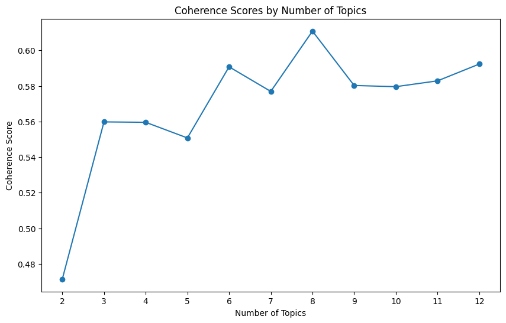

```python
plt.figure(figsize=(10, 6))
plt.plot(topics_range, coherence_scores, marker='o')
plt.title("Coherence Scores by Number of Topics")
plt.xlabel("Number of Topics")
plt.ylabel("Coherence Score")
plt.xticks(topics_range)
plt.show()
```

### 8 topics yields the highest coherence score.

```python
num_topics = 8 # the number of topics we want the model to return
chunksize = 10 # number of documents to be used in each training chunk
passes = 20 # epochs
iterations = 400 # how many times the model iterates over each document during a single pass / epoch
eval_every = 0  # affects speed and quality of the model, can increase for larger datasets

model = LdaModel(
    corpus=corpus,
    id2word=dictionary,
    chunksize=chunksize,
    alpha="auto",
    eta='auto',
    iterations=iterations,
    num_topics=num_topics,
    passes=passes,
    eval_every=eval_every,
    random_state=RANDOM_STATE
)
```

```python
model.show_topics(num_words=20)
```

```
[(0,
  '0.065*"pm" + 0.032*"value" + 0.028*"story" + 0.025*"type" + 0.025*"record" + 0.023*"decision" + 0.016*"advertising" + 0.013*"term" + 0.013*"control" + 0.013*"vote" + 0.013*"relate" + 0.012*"staff" + 0.012*"policy" + 0.012*"concern" + 0.012*"comment" + 0.011*"read" + 0.011*"community" + 0.011*"sel…
 (1,
  '0.014*"star" + 0.012*"reveal" + 0.012*"song" + 0.010*"shoot" + 0.009*"look" + 0.008*"music" + 0.008*"show" + 0.008*"video" + 0.008*"child" + 0.007*"post" + 0.007*"love" + 0.007*"share" + 0.007*"dress" + 0.007*"go" + 0.006*"husband" + 0.006*"season" + 0.006*"wife" + 0.006*"short" + 0.006*"son" + 0…
 (2,
  '0.018*"market" + 0.015*"provide" + 0.015*"datum" + 0.014*"business" + 0.013*"technology" + 0.012*"product" + 0.010*"industry" + 0.010*"growth" + 0.009*"base" + 0.008*"platform" + 0.008*"information" + 0.008*"customer" + 0.007*"design" + 0.007*"build" + 0.007*"release" + 0.007*"solution" + 0.007*"…
 (3,
  '0.014*"game" + 0.013*"deal" + 0.011*"use" + 0.011*"come" + 0.011*"need" + 0.010*"point" + 0.010*"want" + 0.010*"know" + 0.009*"look" + 0.009*"way" + 0.007*"app" + 0.007*"find" + 0.007*"launch" + 0.007*"risk" + 0.007*"play" + 0.007*"thing" + 0.006*"think" + 0.006*"start" + 0.006*"add" + 0.006*"sup…
 (4,
  '0.051*"share" + 0.043*"stock" + 0.036*"price" + 0.021*"quarter" + 0.020*"buy" + 0.018*"market" + 0.017*"report" + 0.016*"sell" + 0.013*"investor" + 0.013*"charge" + 0.013*"earning" + 0.012*"revenue" + 0.012*"analyst" + 0.010*"rate" + 0.010*"rating" + 0.010*"trade" + 0.010*"option" + 0.010*"sale" …
 (5,
  '0.018*"video" + 0.012*"hour" + 0.009*"people" + 0.009*"case" + 0.007*"today" + 0.007*"week" + 0.006*"right" + 0.006*"win" + 0.006*"read" + 0.006*"state" + 0.006*"update" + 0.006*"test" + 0.006*"post" + 0.006*"history" + 0.005*"month" + 0.005*"logo" + 0.005*"file" + 0.005*"police" + 0.005*"feature…
 (6,
  '0.019*"channel" + 0.015*"plan" + 0.014*"rise" + 0.011*"employee" + 0.010*"face" + 0.010*"remain" + 0.009*"vehicle" + 0.009*"rate" + 0.009*"tax" + 0.009*"question" + 0.009*"home" + 0.008*"prepare" + 0.008*"worker" + 0.008*"covid" + 0.008*"gun" + 0.007*"bank" + 0.007*"money" + 0.007*"economy" + 0.0…
 (7,
  '0.041*"open" + 0.034*"link" + 0.030*"cookie" + 0.025*"tab" + 0.016*"website" + 0.016*"user" + 0.015*"people" + 0.014*"link_open" + 0.014*"set" + 0.011*"profile" + 0.011*"podcast" + 0.011*"window" + 0.010*"text" + 0.010*"ad" + 0.009*"visit" + 0.009*"feature" + 0.009*"open_tab" + 0.009*"read" + 0.0…
```

```python
document_topics = [model.get_document_topics(doc) for doc in corpus]
```

```python
len(document_topics)
```

```
5000
```

```python
# Based on the list of words above, I created Labels for the topics

topic_labels = [
    "Politics and Decision Making",
    "Entertainment and Celebrity News",
    "Business and Technology",
    "Games and Apps",
    "Finance and Stock Market",
    "Current News and Events",
    "Economy and Employment",
    "Websites and Online Behavior"
]

# Display topics with labels
for i, (topic, label) in enumerate(zip(model.show_topics(num_words=20), topic_labels)):
    print(f"Topic {i}: {label}")
    print(topic)
    print("\n")
```

```
Topic 0: Politics and Decision Making
(0, '0.065*"pm" + 0.032*"value" + 0.028*"story" + 0.025*"type" + 0.025*"record" + 0.023*"decision" + 0.016*"advertising" + 0.013*"term" + 0.013*"control" + 0.013*"vote" + 0.013*"relate" + 0.012*"staff" + 0.012*"policy" + 0.012*"concern" + 0.012*"comment" + 0.011*"read" + 0.011*"community" + 0.011*"s…


Topic 1: Entertainment and Celebrity News
(1, '0.014*"star" + 0.012*"reveal" + 0.012*"song" + 0.010*"shoot" + 0.009*"look" + 0.008*"music" + 0.008*"show" + 0.008*"video" + 0.008*"child" + 0.007*"post" + 0.007*"love" + 0.007*"share" + 0.007*"dress" + 0.007*"go" + 0.006*"husband" + 0.006*"season" + 0.006*"wife" + 0.006*"short" + 0.006*"son" +…


Topic 2: Business and Technology
(2, '0.018*"market" + 0.015*"provide" + 0.015*"datum" + 0.014*"business" + 0.013*"technology" + 0.012*"product" + 0.010*"industry" + 0.010*"growth" + 0.009*"base" + 0.008*"platform" + 0.008*"information" + 0.008*"customer" + 0.007*"design" + 0.007*"build" + 0.007*"release" + 0.007*"solution" + 0.007…


Topic 3: Games and Apps
(3, '0.014*"game" + 0.013*"deal" + 0.011*"use" + 0.011*"come" + 0.011*"need" + 0.010*"point" + 0.010*"want" + 0.010*"know" + 0.009*"look" + 0.009*"way" + 0.007*"app" + 0.007*"find" + 0.007*"launch" + 0.007*"risk" + 0.007*"play" + 0.007*"thing" + 0.006*"think" + 0.006*"start" + 0.006*"add" + 0.006*"s…


Topic 4: Finance and Stock Market
(4, '0.051*"share" + 0.043*"stock" + 0.036*"price" + 0.021*"quarter" + 0.020*"buy" + 0.018*"market" + 0.017*"report" + 0.016*"sell" + 0.013*"investor" + 0.013*"charge" + 0.013*"earning" + 0.012*"revenue" + 0.012*"analyst" + 0.010*"rate" + 0.010*"rating" + 0.010*"trade" + 0.010*"option" + 0.010*"sale…


Topic 5: Current News and Events
(5, '0.018*"video" + 0.012*"hour" + 0.009*"people" + 0.009*"case" + 0.007*"today" + 0.007*"week" + 0.006*"right" + 0.006*"win" + 0.006*"read" + 0.006*"state" + 0.006*"update" + 0.006*"test" + 0.006*"post" + 0.006*"history" + 0.005*"month" + 0.005*"logo" + 0.005*"file" + 0.005*"police" + 0.005*"featu…


Topic 6: Economy and Employment
(6, '0.019*"channel" + 0.015*"plan" + 0.014*"rise" + 0.011*"employee" + 0.010*"face" + 0.010*"remain" + 0.009*"vehicle" + 0.009*"rate" + 0.009*"tax" + 0.009*"question" + 0.009*"home" + 0.008*"prepare" + 0.008*"worker" + 0.008*"covid" + 0.008*"gun" + 0.007*"bank" + 0.007*"money" + 0.007*"economy" + 0…


Topic 7: Websites and Online Behavior
(7, '0.041*"open" + 0.034*"link" + 0.030*"cookie" + 0.025*"tab" + 0.016*"website" + 0.016*"user" + 0.015*"people" + 0.014*"link_open" + 0.014*"set" + 0.011*"profile" + 0.011*"podcast" + 0.011*"window" + 0.010*"text" + 0.010*"ad" + 0.009*"visit" + 0.009*"feature" + 0.009*"open_tab" + 0.009*"read" + 0…
```

```python
# Get the dominant topic for each document based on the max

dominant_topics = []
for doc_topics in document_topics:
    dominant_topic = max(doc_topics, key=lambda x: x[1])[0]
    dominant_topics.append(dominant_topic)

# Map the dominant topics to labels

topic_labels_mapped = [topic_labels[topic] for topic in dominant_topics]

# Add the topics to dataframe

news_df['Dominant_Topic'] = dominant_topics
news_df['Topic_Label'] = topic_labels_mapped


news_df["text_clean"] = normalized_corpus
news_df["topics"] = document_topics

# Display the dataframe with the new columns

with pd.option_context("display.max_colwidth", 200):
    display(news_df)
```

|  | url | date | language | title | text | Dominant_Topic | Topic_Label | text_clean | topics |
| --- | --- | --- | --- | --- | --- | --- | --- | --- | --- |
| 3844 | https://www.kxii.com/prnewswire/2022/05/23/computex-2022-global-press-conference-industry-leaders-gather-unlock-future-trends/ | 2022-05-23 | en | COMPUTEX 2022 Global Press Conference Industry Leaders Gather to Unlock Future Trends | COMPUTEX 2022 Global Press Conference Industry Leaders Gather to Unlock Future TrendsSkip to contentTexoma LocalExpert AdviceTexoma EatsNewsWeatherSportsSend Us Your News TipWatch LiveSearchHomepa... | 2 | Business and Technology | [computex, leader, contenttexoma, eatsnewsweathersportssend, livesearchhomepagelivestreamnewstexasoklahomaregionalinternationalnationalfireaccidentscrimeeducationsend, news, careersscheduleviewe, ... | [(1, 0.011551469), (2, 0.7474921), (4, 0.023047546), (5, 0.19951026)] |
| 3617 | https://www.bigrapidsnews.com/business/article/Moderna-Roku-rise-Scotts-Miracle-Gro-Charles-17228702.php | 2022-06-09 | en | Moderna, Roku rise; Scotts Miracle-Gro, Charles River fall | Moderna, Roku rise; Scotts Miracle-Gro, Charles River fall Skip to main content Big Rapids Pioneer HomepageCurrently ReadingModerna, Roku rise; Scotts Miracle-Gro, Charles River fallSubscri... | 4 | Finance and Stock Market | [roku, rise, fall, content, rise, fallsubscribesubscribee, sportsopinioncolumnsletter, editorobituariessubmit, suspect, assault, cooperate, authority, get, snake, racer, snake, report, way, end, s... | [(0, 0.014665059), (1, 0.07637952), (2, 0.035342187), (3, 0.042253356), (4, 0.5184604), (5, 0.2430386), (6, 0.056336954), (7, 0.013523899)] |
| 2608 | https://www.devdiscourse.com/article/education/2000652-create-entrepreneurship-ecosystem-in-districts-to-drive-local-jobs-ktaka-task-force-to-govt | 2022-04-12 | en | Create entrepreneurship ecosystem in districts to drive local jobs: K'taka task force to govt \| Education | Create entrepreneurship ecosystem in districts to drive local jobs: K'taka task force to govt \| Education HOME NEWS RESEARCH LIVE DISCOURSE BLOG / OPINION SUBMIT PRESS RE... | 5 | Current News and Events | [create, entrepreneurship, ecosystem, district, drive, job, task, force, blog, submit, blog, wash, advertisement, create, entrepreneurship, ecosystem, district, drive, job, task, force, govt, upda... | [(1, 0.012699931), (2, 0.33867648), (3, 0.047033016), (4, 0.017397765), (5, 0.48947966), (6, 0.07791387), (7, 0.013916338)] |
| 3857 | https://www.seattletimes.com/seattle-news/health/connecticut-senate-oks-bill-that-protects-abortion-providers/?utm_source=RSS&utm_medium=Referral&utm_campaign=RSS_all | 2022-04-30 | en | Connecticut Senate OKs bill that protects abortion providers \| The Seattle Times | Connecticut Senate OKs bill that protects abortion providers \| The Seattle Times Skip to contentCoronavirusLocal NewsTraffic LabLaw & JusticeLocal PoliticsEducationEducation LabEastsideEnvironme... | 0 | Politics and Decision Making | [bill, protect, abortion, provider, labeastsideenvironmenthealthdatamental, radioentertainmentmoviesbooksmusictheaterclassical, labeastsideenvironmentnorthwestdatahealthtime, intelligencemicrosoft... | [(0, 0.68242216), (1, 0.02284081), (2, 0.022134284), (3, 0.033821158), (5, 0.22118026)] |
| 1595 | https://www.breakinglatest.news/news/maturity-thanks-from-fabio-and-adriana-inclusion-put-into-practice-every-day-so-our-alessandro-graduated/ | 2022-07-24 | en | Maturity, thanks from Fabio and Adriana: “Inclusion put into practice every day, so our Alessandro graduated”-breakinglatest.news-Breaking Latest News | Maturity, thanks from Fabio and Adriana: “Inclusion put into practice every day, so our Alessandro graduated”-breakinglatest.news-Breaking Latest NewsHomeBusinessEntertainmentHealthNewsSportsTechn... | 3 | Games and Apps | [thank, practice, day, break, thank, practice, day, thank, practice, day, tell, story, son, path, syndrome, thank, stand, path, thank, patience, teacher, support, classmate, support, parent, obtai... | [(0, 0.021677021), (1, 0.10633812), (2, 0.039783772), (3, 0.56293166), (5, 0.21260102), (6, 0.013318549), (7, 0.03958571)] |
| ... | ... | ... | ... | ... | ... | ... | ... | ... | ... |
| 4397 | https://www.benzinga.com/quote/ODP | 2022-02-24 | en | ODP (NASDAQ:ODP) Stock Price, News, Charts - Benzinga | ODP (NASDAQ:ODP) Stock Price, News, Charts - BenzingaMy accountMy AccountLog InForgot PasswordQQQ––%DIA––%SPY––%TLT––%GLD––%BTC/USD––%Data & APIsEventsMarketfyPremarketContributeSign inNews Earnin... | 4 | Finance and Stock Market | [innew, salesofferingsiposinsider, fdafreightpoliticsgovernmenthealthcaremarket, capcryptocurrencypenny, volume, brokersetf, reviewsinsuranceautohomemedicarelifevisiondentalbusinesspethealthmotorc... | [(0, 0.01621074), (2, 0.26335686), (3, 0.11146737), (4, 0.52221435), (5, 0.06777488), (6, 0.013488189)] |
| 8697 | https://gadgets360.com/mobiles/news/motorola-moto-g22-price-eur-200-mediatek-helio-g37-soc-specifications-leak-2773125 | 2022-02-17 | en | Moto G22 Price, Specifications Leak; MediaTek Helio G37 SoC and Triple Rear Cameras Tipped \| Technology News | Moto G22 Price, Specifications Leak; MediaTek Helio G37 SoC and Triple Rear Cameras Tipped \| Technology News ... | 3 | Games and Apps | [tip, product, tv, tablet, console, tv, tablet, console, plan, price, rate, deal, mobile, tv, pc, tip, tip, say, come, price, tag, update, say, camera, sensor, tip, feature, rate, display, say, co... | [(1, 0.019519044), (2, 0.120639704), (3, 0.5394008), (4, 0.10068497), (5, 0.076552376), (6, 0.051114652), (7, 0.083292104)] |
| 5873 | https://www.seattletimes.com/sports/boston-leads-no-1-south-carolina-to-69-40-win-over-ole-miss/?utm_source=RSS&utm_medium=Referral&utm_campaign=RSS_all | 2022-01-28 | en | Boston leads No. 1 South Carolina to 69-40 win over Ole Miss \| The Seattle Times | Boston leads No. 1 South Carolina to 69-40 win over Ole Miss \| The Seattle Times Skip to contentCoronavirusLocal NewsTraffic LabLaw & JusticeLocal PoliticsEducationEducation LabEastsideEnvironmen... | 0 | Politics and Decision Making | [lead, win, labeastsideenvironmenthealthdatamental, radioentertainmentmoviesbooksmusictheaterclassical, labeastsideenvironmentnorthwestdatahealthtime, intelligencemicrosofttechnologyeconomyreal, s... | [(0, 0.3012688), (1, 0.14761618), (2, 0.023611644), (3, 0.16753444), (4, 0.038086586), (5, 0.19523539), (6, 0.12429606)] |
| 6123 | https://www.thenationalnews.com/business/markets/2022/07/20/netflix-quarterly-profit-jumps-despite-losing-970000-subscribers/ | 2022-07-20 | en | Netflix loses 970,000 subscribers but quarterly profit jumps | Netflix loses 970,000 subscribers but quarterly profit jumpsWednesday 20 July 2022weather_iconWhite circle red arrow SIGN UPUAECourtsGovernmentEducationHeritageHealthTransportScienceEnvironmentMeg... | 4 | Finance and Stock Market | [lose, subscriber, profit, circle, arrow, upuaecourtsgovernmenteducationheritagehealthtransportscienceenvironmentmegaprojectsexpo, zerofuturecommentopinioncommenteditorialobituariescartoonfeedback... | [(0, 0.020963032), (1, 0.046335857), (2, 0.2001536), (3, 0.22582419), (4, 0.33676103), (5, 0.07920034), (6, 0.06660327), (7, 0.024158701)] |
| 1212 | https://gizmodo.com/metas-head-of-pr-leaves-a-company-on-fire-1848327562 | 2022-01-09 | en | Meta's Head of PR Leaves a Company on Fire | Meta's Head of PR Leaves a Company on FireThe A.V. ClubDeadspinGizmodoJalopnikJezebelKotakuLifehackerThe RootThe TakeoutThe OnionThe InventoryWe come from the futureShopSubscribeHomeLatestCES 2022... | 5 | Current News and Events | [leave, company, inventorywe, come, futureshopsubscribehomelatestces, come, sitesadvertisingprivacyjobsterm, mediahomelatestces, leave, company, departure, come, struggle, address, controversy, wa... | [(0, 0.03254682), (1, 0.08237792), (2, 0.06436646), (3, 0.22931097), (4, 0.036360763), (5, 0.37611616), (6, 0.1583458), (7, 0.020575112)] |

5000 rows × 9 columns

# NMF

```python
# Ensure that each document in normalized_corpus is a single string.
# If the document is a list of tokens, it combines the tokens into a string;
# if it's already a string, it remains unchanged.

normalized_corpus = [" ".join(doc) if isinstance(doc, list) else doc for doc in normalized_corpus]
```

```python
normalized_corpus[0]
```

```
'computex leader contenttexoma eatsnewsweathersportssend livesearchhomepagelivestreamnewstexasoklahomaregionalinternationalnationalfireaccidentscrimeeducationsend news careersscheduleviewe watch releasescomputex leader minute await kick run week organize exhibition break barrier limitation connect b…
```

```python
len(normalized_corpus)
```

```
5000
```

```python
# having to vectorize text first

tfidf_vect = TfidfVectorizer(max_df=0.95, min_df=2)
tfidf = tfidf_vect.fit_transform(normalized_corpus)
```

```python
# dimensions of (docs, words)

tfidf.shape
```

```
(5000, 41114)
```

```python
# try 10 topics first

RANDOM_STATE = 0

n_topics = 10
nmf = NMF(n_components=n_topics, init="nndsvd", random_state=RANDOM_STATE)
W = nmf.fit_transform(tfidf) # corresponds to H^T in literature
H = nmf.components_ # corresponds to W^T in literature
```

```python
# shape of docs x topics
W.shape
```

```
(5000, 10)
```

```python
H.shape
```

```
(10, 41114)
```

### [:-11:-1] means "take the last 10 elements in reverse order"

```python
feature_names = tfidf_vect.get_feature_names_out()

# H is the topics x words matrix so iterating through every row is like iterating over each topic # what is the words comp of each topic
# and looking at the column values is like looking at the which word has higher scores

for topic_idx, words in enumerate(H):
    print(f"Topic #{topic_idx}:")

    # argsort() returns indices that would sort the array in ASCENDING order
    # [:-11:-1] starts from the last element and moves backward (due to -1), picking the last 10 elements because it stops before the 11th-to-last element
    # this effectiveyl selects the indices of the largest values in words
    # and large values in topic model context here represent important topic words

    print(" ".join([feature_names[i] for i in words.argsort()[:-11:-1]]))  # indices of the top 10 most important words! map indices to actual words feature_names[i]
    print("\n")
```

```
Topic #0:
say radioentertainmentmoviesbooksmusictheaterclassical advertising pm story state people staff police community


Topic #1:
tab open link_open link open_tab podcast dialog profile_manage window tab_link


Topic #2:
account twitter delay disclosure datum minute company author profile visit


Topic #3:
share stock rating quarter company analyst earning buy ratio price


Topic #4:
market growth industry company report business provide technology application solution


Topic #5:
inflation stock rate say rise price recession hike market economic


Topic #6:
cookie user cookie_set website visitor set description store set_cookie ad


Topic #7:
game deal gaming pc feature app laptop tv user video


Topic #8:
star dress reveal husband daughter wife say child look film


Topic #9:
symbol stock add separate_space add_appear symbol_want symbolsto symbol_site availableedit paste_symbol
```

```python
news_df
```

|  | url | date | language | title | text | Dominant_Topic | Topic_Label | text_clean | topics |
| --- | --- | --- | --- | --- | --- | --- | --- | --- | --- |
| 3844 | https://www.kxii.com/prnewswire/2022/05/23/com... | 2022-05-23 | en | COMPUTEX 2022 Global Press Conference Industry... | COMPUTEX 2022 Global Press Conference Industry... | 2 | Business and Technology | [computex, leader, contenttexoma, eatsnewsweat... | [(1, 0.011551469), (2, 0.7474921), (4, 0.02304... |
| 3617 | https://www.bigrapidsnews.com/business/article... | 2022-06-09 | en | Moderna, Roku rise; Scotts Miracle-Gro, Charle... | Moderna, Roku rise; Scotts Miracle-Gro, Charle... | 4 | Finance and Stock Market | [roku, rise, fall, content, rise, fallsubscrib... | [(0, 0.014665059), (1, 0.07637952), (2, 0.0353... |
| 2608 | https://www.devdiscourse.com/article/education... | 2022-04-12 | en | Create entrepreneurship ecosystem in districts... | Create entrepreneurship ecosystem in districts... | 5 | Current News and Events | [create, entrepreneurship, ecosystem, district... | [(1, 0.012699931), (2, 0.33867648), (3, 0.0470... |
| 3857 | https://www.seattletimes.com/seattle-news/heal... | 2022-04-30 | en | Connecticut Senate OKs bill that protects abor... | Connecticut Senate OKs bill that protects abor... | 0 | Politics and Decision Making | [bill, protect, abortion, provider, labeastsid... | [(0, 0.68242216), (1, 0.02284081), (2, 0.02213... |
| 1595 | https://www.breakinglatest.news/news/maturity-... | 2022-07-24 | en | Maturity, thanks from Fabio and Adriana: “Incl... | Maturity, thanks from Fabio and Adriana: “Incl... | 3 | Games and Apps | [thank, practice, day, break, thank, practice,... | [(0, 0.021677021), (1, 0.10633812), (2, 0.0397... |
| ... | ... | ... | ... | ... | ... | ... | ... | ... | ... |
| 4397 | https://www.benzinga.com/quote/ODP | 2022-02-24 | en | ODP (NASDAQ:ODP) Stock Price, News, Charts - B... | ODP (NASDAQ:ODP) Stock Price, News, Charts - B... | 4 | Finance and Stock Market | [innew, salesofferingsiposinsider, fdafreightp... | [(0, 0.01621074), (2, 0.26335686), (3, 0.11146... |
| 8697 | https://gadgets360.com/mobiles/news/motorola-m... | 2022-02-17 | en | Moto G22 Price, Specifications Leak; MediaTek ... | Moto G22 Price, Specifications Leak; M... | 3 | Games and Apps | [tip, product, tv, tablet, console, tv, tablet... | [(1, 0.019519044), (2, 0.120639704), (3, 0.539... |
| 5873 | https://www.seattletimes.com/sports/boston-lea... | 2022-01-28 | en | Boston leads No. 1 South Carolina to 69-40 win... | Boston leads No. 1 South Carolina to 69-40 win... | 0 | Politics and Decision Making | [lead, win, labeastsideenvironmenthealthdatame... | [(0, 0.3012688), (1, 0.14761618), (2, 0.023611... |
| 6123 | https://www.thenationalnews.com/business/marke... | 2022-07-20 | en | Netflix loses 970,000 subscribers but quarterl... | Netflix loses 970,000 subscribers but quarterl... | 4 | Finance and Stock Market | [lose, subscriber, profit, circle, arrow, upua... | [(0, 0.020963032), (1, 0.046335857), (2, 0.200... |
| 1212 | https://gizmodo.com/metas-head-of-pr-leaves-a-... | 2022-01-09 | en | Meta's Head of PR Leaves a Company on Fire | Meta's Head of PR Leaves a Company on FireThe ... | 5 | Current News and Events | [leave, company, inventorywe, come, futureshop... | [(0, 0.03254682), (1, 0.08237792), (2, 0.06436... |

5000 rows × 9 columns

```python
doc_idx = 3

# W is shape of docs x topics
# so this output shows us the topic contribution to document doc_idx
print(W[doc_idx].tolist())
print()
print("Index of maximum value:", W[doc_idx].argmax())
```

```
[0.08729952607926282, 0.0, 0.0, 0.0, 0.0, 0.0, 0.00029020313616910046, 0.0, 0.0, 0.0]

Index of maximum value: 0
```

NMF is a matrix factorization technique that approximates the original document-term matrix (like a TF-IDF matrix) into two non-negative matrices: one representing the topic weights for each document (W) and the other representing the word weights for each topic (H).

The values in W[doc_idx] represent **the contribution of each topic to the document doc_idx, but they are not probabilities and are not required to sum to 1**.

The values are just **the weights indicating how much each topic contributes to that specific document**, and they can take any non-negative values.

```python
# we can find the most likely topic for each article with the following
# finds the index of the maximum value along the row
# W.argmax(axis=1) will return, for each row (document), the index of the column (topic) that has the largest value.

W.argmax(axis=1)
```

```
array([4, 5, 4, ..., 0, 3, 4], dtype=int64)
```

### Tuning NMF

```python
n_topics = 8
nmf = NMF(n_components=n_topics, init="nndsvd", random_state=RANDOM_STATE)
W = nmf.fit_transform(tfidf) # corresponds to H^T in literature
H = nmf.components_ # corresponds to W^T in literature
```

```python
# H is the topics x words matrix so iterating through every row is like iterating over each topic
# and looking at the column values is like looking at the which word has higher scores

for topic_idx, words in enumerate(H):
    print(f"Topic #{topic_idx}:")

    # argsort() returns indices that would sort the array in ASCENDING order
    # [:-11:-1] starts from the last element and moves backward (due to -1), picking the last 10 elements because it stops before the 11th-to-last element
    # this effectiveyl selects the indices of the largest values in words
    # and large values in topic model context here represent import topic words
    print(" ".join([feature_names[i] for i in words.argsort()[:-21:-1]]))
    print("\n")
```

```
Topic #0:
say star year reveal day child dress hour people woman radioentertainmentmoviesbooksmusictheaterclassical man police state family comment husband post go wife


Topic #1:
tab open link_open link open_tab podcast dialog profile_manage window tab_link people notification profile manage dialog_window date open_open work_have browser way


Topic #2:
account twitter delay disclosure datum minute company author profile visit provide delay_price base_minute fall delay_basis provide_minute week member option article


Topic #3:
share stock rating quarter company analyst earning buy ratio price share_quarter own research dividend sell own_share report stake value stock_value


Topic #4:
market growth industry company business report provide technology solution application customer datum cloud service product analysis revenue forecast research include


Topic #5:
stock inflation rate say rise price market recession investor hike year oil economic economy fall symbol bank plan see risk


Topic #6:
cookie user cookie_set website visitor set description store set_cookie ad cookie_store consent collect datum target use information visit domain track


Topic #7:
game deal gaming pc feature pm app laptop tv user play video launch review come use console hour phone player
```

```python
# now try 3 topics

n_topics = 3
nmf = NMF(n_components=n_topics, init="nndsvd", random_state=RANDOM_STATE)
W = nmf.fit_transform(tfidf) # corresponds to H^T in literature
H = nmf.components_ # corresponds to W^T in literature
```

```python
# H is the topics x words matrix so iterating through every row is like iterating over each topic
# and looking at the column values is like looking at the which word has higher scores

for topic_idx, words in enumerate(H):
    print(f"Topic #{topic_idx}:")

    # argsort() returns indices that would sort the array in ASCENDING order
    # [:-11:-1] starts from the last element and moves backward (due to -1), picking the last 10 elements because it stops before the 11th-to-last element
    # this effectiveyl selects the indices of the largest values in words
    # and large values in topic model context here represent import topic words
    print(" ".join([feature_names[i] for i in words.argsort()[:-21:-1]]))
    print("\n")
```

```
Topic #0:
stock share company say market year quarter price rating report buy earning day game sell analyst rate business investor hour


Topic #1:
open tab link link_open open_tab podcast dialog window profile_manage people tab_link star notification say profile manage dialog_window date open_open way


Topic #2:
account twitter delay disclosure datum provide company minute visit author profile market delay_price base_minute fall delay_basis provide_minute option member week
```

```python
# now try 12 topics

n_topics = 12
nmf = NMF(n_components=n_topics, init="nndsvd", random_state=RANDOM_STATE)
W = nmf.fit_transform(tfidf) # corresponds to H^T in literature
H = nmf.components_ # corresponds to W^T in literature
```

```python
# H is the topics x words matrix so iterating through every row is like iterating over each topic
# and looking at the column values is like looking at the which word has higher scores

for topic_idx, words in enumerate(H):
    print(f"Topic #{topic_idx}:")

    # argsort() returns indices that would sort the array in ASCENDING order
    # [:-11:-1] starts from the last element and moves backward (due to -1), picking the last 10 elements because it stops before the 11th-to-last element
    # this effectiveyl selects the indices of the largest values in words
    # and large values in topic model context here represent import topic words
    print(" ".join([feature_names[i] for i in words.argsort()[:-21:-1]]))
    print("\n")
```

```
Topic #0:
market report growth forecast analysis segment research industry application revenue player provide size region forecast_period factor product market_size period study


Topic #1:
tab open link_open link open_tab podcast dialog profile_manage window tab_link people notification profile manage dialog_window open_open date work_have browser way


Topic #2:
account twitter delay disclosure datum minute company author profile visit provide delay_price base_minute fall delay_basis provide_minute week member option article


Topic #3:
share stock rating quarter company analyst earning buy ratio price share_quarter own research dividend sell own_share report stake value stock_value


Topic #4:
company technology customer solution cloud business security platform datum service release provide user organization press_release software work experience team management


Topic #5:
inflation stock rate say rise price recession hike economic oil year investor economy market fall bank plan see risk ceo


Topic #6:
cookie user cookie_set website visitor set description store set_cookie ad cookie_store consent collect target datum use information domain track visit


Topic #7:
game deal gaming pc laptop tv play video feature console pm player launch review app hour come open tablet phone


Topic #8:
star dress reveal husband daughter say wife child look year show film son figure post bikini share baby birthday ex


Topic #9:
symbol stock add availableedit symbol_site paste_symbol symbol_want symbolsto add_appear separate_space press_copy add_select trend paste quote separate session play select copy


Topic #10:
say radioentertainmentmoviesbooksmusictheaterclassical pm advertising story state staff storecontactfaqssubscriber listingsclassifiedspaid solutionsst newslettersfacebooktwitterrssnewspaper clementtraveloutdoorsnorthwest companyaboutcontactcareerspermissionsnewsroom intelligencemicrosofttechnologyec…


Topic #11:
chapter click promptsfind sciencedecentralizationfinancefuturismgaminghardware click_sciencedecentralizationfinancefuturismgaminghardware faqsstory faqsstory_use uscareerspodcastjoin come_soonhelpwriterswe soonhelpwriterswe editorcontactvisitorswhat_navigate editorcontactvisitorswhat updatespeoplece…
```

### I will choose 8 topics for NMF as it becomes uninterpretable at higher number of topics as seen above

```python
n_topics = 8
nmf = NMF(n_components=n_topics, init="nndsvd", random_state=RANDOM_STATE)
W = nmf.fit_transform(tfidf) # corresponds to H^T in literature
H = nmf.components_ # corresponds to W^T in literature
```

```python
# H is the topics x words matrix so iterating through every row is like iterating over each topic
# and looking at the column values is like looking at the which word has higher scores

for topic_idx, words in enumerate(H):
    print(f"Topic #{topic_idx}:")

    # argsort() returns indices that would sort the array in ASCENDING order
    # [:-11:-1] starts from the last element and moves backward (due to -1), picking the last 10 elements because it stops before the 11th-to-last element
    # this effectiveyl selects the indices of the largest values in words
    # and large values in topic model context here represent import topic words
    print(" ".join([feature_names[i] for i in words.argsort()[:-21:-1]]))
    print("\n")
```

```
Topic #0:
say star year reveal day child dress hour people woman radioentertainmentmoviesbooksmusictheaterclassical man police state family comment husband post go wife


Topic #1:
tab open link_open link open_tab podcast dialog profile_manage window tab_link people notification profile manage dialog_window date open_open work_have browser way


Topic #2:
account twitter delay disclosure datum minute company author profile visit provide delay_price base_minute fall delay_basis provide_minute week member option article


Topic #3:
share stock rating quarter company analyst earning buy ratio price share_quarter own research dividend sell own_share report stake value stock_value


Topic #4:
market growth industry company business report provide technology solution application customer datum cloud service product analysis revenue forecast research include


Topic #5:
stock inflation rate say rise price market recession investor hike year oil economic economy fall symbol bank plan see risk


Topic #6:
cookie user cookie_set website visitor set description store set_cookie ad cookie_store consent collect datum target use information visit domain track


Topic #7:
game deal gaming pc feature pm app laptop tv user play video launch review come use console hour phone player
```

```python
# Stick with 8
# assinign topic to the original dataframe

topic_map = {
    0: "Entertainment and Celebrities",
    1: "Technology and Internet",
    2: "Social Media and Online Accounts",
    3: "Finance and Stock Market",
    4: "Business and Technology",
    5: "Economy and Inflation",
    6: "Privacy and Data Collection",
    7: "Gaming and Technology"
}


# W is the document-topic matrix and we are taking the maximum value (topic contribution) for each row (document)
news_df["topics_NMF"] = W.argmax(axis=1)
news_df["topic_names_NMF"] = pd.Series(W.argmax(axis=1)).map(topic_map)
```

```python
news_df.head(10)
```

|  | url | date | language | title | text | Dominant_Topic | Topic_Label | text_clean | topics | topics_NMF | topic_names_NMF |
| --- | --- | --- | --- | --- | --- | --- | --- | --- | --- | --- | --- |
| 3844 | https://www.kxii.com/prnewswire/2022/05/23/com... | 2022-05-23 | en | COMPUTEX 2022 Global Press Conference Industry... | COMPUTEX 2022 Global Press Conference Industry... | 2 | Business and Technology | [computex, leader, contenttexoma, eatsnewsweat... | [(1, 0.011551469), (2, 0.7474921), (4, 0.02304... | 4 | Entertainment and Celebrities |
| 3617 | https://www.bigrapidsnews.com/business/article... | 2022-06-09 | en | Moderna, Roku rise; Scotts Miracle-Gro, Charle... | Moderna, Roku rise; Scotts Miracle-Gro, Charle... | 4 | Finance and Stock Market | [roku, rise, fall, content, rise, fallsubscrib... | [(0, 0.014665059), (1, 0.07637952), (2, 0.0353... | 5 | Gaming and Technology |
| 2608 | https://www.devdiscourse.com/article/education... | 2022-04-12 | en | Create entrepreneurship ecosystem in districts... | Create entrepreneurship ecosystem in districts... | 5 | Current News and Events | [create, entrepreneurship, ecosystem, district... | [(1, 0.012699931), (2, 0.33867648), (3, 0.0470... | 4 | Economy and Inflation |
| 3857 | https://www.seattletimes.com/seattle-news/heal... | 2022-04-30 | en | Connecticut Senate OKs bill that protects abor... | Connecticut Senate OKs bill that protects abor... | 0 | Politics and Decision Making | [bill, protect, abortion, provider, labeastsid... | [(0, 0.68242216), (1, 0.02284081), (2, 0.02213... | 0 | Business and Technology |
| 1595 | https://www.breakinglatest.news/news/maturity-... | 2022-07-24 | en | Maturity, thanks from Fabio and Adriana: “Incl... | Maturity, thanks from Fabio and Adriana: “Incl... | 3 | Games and Apps | [thank, practice, day, break, thank, practice,... | [(0, 0.021677021), (1, 0.10633812), (2, 0.0397... | 0 | Gaming and Technology |
| 6803 | https://www.wyomingnews.com/wyomingbusinessrep... | 2022-07-29 | en | U.S. government says $401M will add broadband ... | U.S. government says $401M will add broadband ... | 5 | Current News and Events | [government, say, add, contentyou, permission,... | [(2, 0.07862394), (3, 0.15015532), (4, 0.02799... | 4 | NaN |
| 2984 | https://people.com/home/christina-hall-gushes-... | 2022-05-31 | en | Christina Hall Gushes Over Her Husband Josh Ha... | Christina Hall Gushes Over Her Husband J... | 7 | Websites and Online Behavior | [gush, content, smile, tv, shopping, test, pod... | [(1, 0.1774073), (3, 0.01479972), (4, 0.028728... | 1 | Entertainment and Celebrities |
| 8848 | https://www.dailymail.co.uk/news/article-10580... | 2022-03-05 | en | Shopkeeper who told 81-year-old his EuroMillio... | Shopkeeper who told 81-year-old his EuroMillio... | 1 | Entertainment and Celebrity News | [shopkeeper, tell, year, ticket, loser, jail, ... | [(1, 0.68770653), (3, 0.122643225), (4, 0.0214... | 0 | NaN |
| 1761 | https://www.prudentpressagency.com/chile-and-v... | 2022-04-06 | en | Chile and Venezuela sign memorandum of underst... | Chile and Venezuela sign memorandum of underst... | 5 | Current News and Events | [sign, memorandum, understanding, expand, air,... | [(1, 0.023698159), (2, 0.03469071), (3, 0.0976... | 0 | Business and Technology |
| 8679 | https://www.newsbreak.com/news/2678484482710/s... | 2022-07-28 | en | Stark County roundup: News from around the Can... | Stark County roundup: News from around the Can... | 6 | Economy and Employment | [roundup, news, region, politicsmilitarycongre... | [(1, 0.093787104), (2, 0.023121934), (3, 0.034... | 0 | NaN |

# Model Results

My comparison between LDA and NMF highlights key differences in topic modeling approaches:

- **LDA (Latent Dirichlet Allocation)**: LDA provides a probabilistic approach, offering distinguishable topics with some overlap and leveraging tools like coherence score to determine the optimal number of topics. It tends to be slower but offers clearer metrics for topic quality, making it easier to tune the model. I achieved a higher coherence score with 8 topics and labeled them uniquely, which suggests LDA provided more meaningful and interpretable results for my dataset.
- **NMF (Non-Negative Matrix Factorization)**: NMF is a faster matrix factorization technique, allowing me to experiment with different numbers of topics quickly. However, as I noted, there’s no direct metric like coherence score, making it harder to tune effectively. My experiment with 3, 8 and 12 topics showed that having too many/few topics can lead to "glued" tokens that are less comprehensible. NMF missed or misclassified some articles compared to LDA. So both LDA and NMF chose 8 topics.

### Summary:

- **LDA** was slower but provided more reliable topics with a higher coherence score.
- **NMF** was faster and allowed more flexibility in experimenting with the number of topics, but it lacked the fine-tuned interpretability and comprehensiveness of LDA.

My analysis suggests that LDA might be more appropriate when topic coherence and detailed topic assignments are crucial, while NMF might be useful for quicker, large-scale experiments or when computational efficiency is important.

# Challenges

When comparing **LDA** and **NMF**, both have some challenges:

- **LDA** slower and more demanding on memory because it's a probabilistic model and requires multiple iterations (like Gibbs sampling) to estimate topic distributions. This makes it more computationally intensive, especially with larger datasets, which increases run time and memory usage.
- **NMF** runs faster and is generally more memory-efficient since it uses matrix factorization instead of complex probabilistic calculations. Since there’s no clear metric like coherence score, it requires more trial and error to find the right number of topics.

Overall, **LDA** takes more time and resources but often provides better interpretability, while **NMF** is quicker but needs more experimentation to fine-tune the topics.